# E-News Express Project

The company is an online news portal which aims to increase its business by acquiring new subscribers. So its business model is based on subscription fees paid by the customer. The objective of E-News Express is to evaluate whether the new landing page will be more effective than the old one.They use A/B testing method to decide which variant of landing page is more effective. Here you have two landing pages ( the old and the newly created ). our task is to decide whether the new landing is more effective in gahtering new subscribers. For that purpose we use randomly selecty sample of 100 users and divid them into 2 groups. the old landing page is the control group and the new landing page is the treatment group. All the data are collectd in the csv file "abtest". Key questions are : 1.Explore Data an extract insights with Exploratory Data Analysis (EDA) 2.Compare the time spent by the users of the 2 groups ( contron and treatment group)? 3.calculate the conversion rate for two groups and decide if the CR ( conversion rate ) the treatment group is greater than the one of the control group? 4.Find out if the conversion is related to a preferred language ? 5. Test the hypothesis stating that the mean time spent on the new page is equal for different language users

```python
import pandas as pd
import matplotlib.pyplot as plt
import seaborn as sns
import warnings
warnings.filterwarnings("ignore")
from PIL import Image
%matplotlib inline
sns.set(color_codes=True)
from scipy import stats
```

Import the CSV file

```python
enews=pd.read_csv('C:\\Users\\Missoup Etienne\\OneDrive\\Documents\\HPSCANS\\Perso\\Future trainings\\DSBA program Texas Austin\\Business Statistics\\project 2\\abtest.csv')
```

Checking the five first rows of the data

```python
enews.head()
```

|  | user_id | group | landing_page | time_spent_on_the_page | converted | language_preferred |
| --- | --- | --- | --- | --- | --- | --- |
| 0 | 546592 | control | old | 3.48 | no | Spanish |
| 1 | 546468 | treatment | new | 7.13 | yes | English |
| 2 | 546462 | treatment | new | 4.40 | no | Spanish |
| 3 | 546567 | control | old | 3.02 | no | French |
| 4 | 546459 | treatment | new | 4.75 | yes | Spanish |

we have 6 columns here:

1.User_id which represents the user ID of the person visiting the website 2.group which states whether the visitor belong to the control group or the treatment group 3.landing page which represents whether the new landing page or the old one. 4.time_spent_on_the_page which is the time in minutes spent by a given user on a landing page 5.Converted which is the status of user converted into subscriber of the news portal or not 6.language_preferred which the language chosen by the user to new landing page.

```python
#Check the shape of the dataset, we have 100 rows (users) and 6 columns
enews.shape
```

```
(100, 6)
```

```python
#Check the info(), all columns have 100 entries meaning there is no missing values, group, landing page converted and language are categorical variables
enews.info()
```

```
<class 'pandas.core.frame.DataFrame'>
RangeIndex: 100 entries, 0 to 99
Data columns (total 6 columns):
 #   Column                  Non-Null Count  Dtype
---  ------                  --------------  -----
 0   user_id                 100 non-null    int64
 1   group                   100 non-null    object
 2   landing_page            100 non-null    object
 3   time_spent_on_the_page  100 non-null    float64
 4   converted               100 non-null    object
 5   language_preferred      100 non-null    object
dtypes: float64(1), int64(1), object(4)
memory usage: 4.8+ KB
```

```python
# I will copy the dataset to keep the original ( data Preprocessing for futher studies)
df=enews.copy()
```

```python
#Fixing the datatype, we tried to convert categorical column into categorical type to reduce the space and better data manipulation.  We should transform the user id also into categorical data. I will continue with df
df['group'] = df.group.astype('category')
df['landing_page'] = df.landing_page.astype('category')
df['converted'] = df.converted.astype('category')
df['language_preferred'] = df.language_preferred.astype('category')
df.info()
```

```
<class 'pandas.core.frame.DataFrame'>
RangeIndex: 100 entries, 0 to 99
Data columns (total 6 columns):
 #   Column                  Non-Null Count  Dtype
---  ------                  --------------  -----
 0   user_id                 100 non-null    int64
 1   group                   100 non-null    category
 2   landing_page            100 non-null    category
 3   time_spent_on_the_page  100 non-null    float64
 4   converted               100 non-null    category
 5   language_preferred      100 non-null    category
dtypes: category(4), float64(1), int64(1)
memory usage: 2.5 KB
```

# checking summary of the Data

```python
#summary of data. Here we have only the time which is the only one numerical  variable. we see that the time goes up to 10 minutes.
df.describe(include="all").T
```

|  | count | unique | top | freq | mean | std | min | 25% | 50% | 75% | max |
| --- | --- | --- | --- | --- | --- | --- | --- | --- | --- | --- | --- |
| user_id | 100 | NaN | NaN | NaN | 546517 | 52.2958 | 546443 | 546468 | 546492 | 546567 | 546592 |
| group | 100 | 2 | treatment | 50 | NaN | NaN | NaN | NaN | NaN | NaN | NaN |
| landing_page | 100 | 2 | old | 50 | NaN | NaN | NaN | NaN | NaN | NaN | NaN |
| time_spent_on_the_page | 100 | NaN | NaN | NaN | 5.3778 | 2.37817 | 0.19 | 3.88 | 5.415 | 7.0225 | 10.71 |
| converted | 100 | 2 | yes | 54 | NaN | NaN | NaN | NaN | NaN | NaN | NaN |
| language_preferred | 100 | 3 | Spanish | 34 | NaN | NaN | NaN | NaN | NaN | NaN | NaN |

```python
# Check for missing value in any column. There is no missing value. good news.
df.isnull().sum()
```

```
user_id                   0
group                     0
landing_page              0
time_spent_on_the_page    0
converted                 0
language_preferred        0
dtype: int64
```

Plotting histograms and box plot to visualize the raw data

```python
df.mean()
```

```
user_id                   546517.0000
time_spent_on_the_page         5.3778
dtype: float64
```

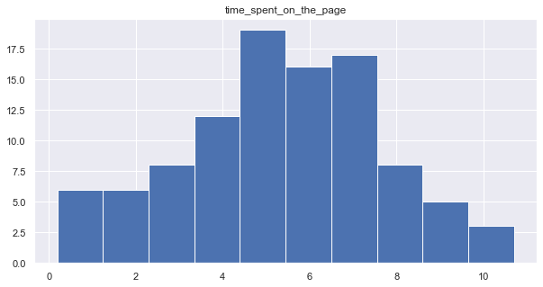

```python
df.iloc[:,1:6].hist(figsize=(10,5)) # we see a good shape of the  time spent by user on the page
plt.show()
```

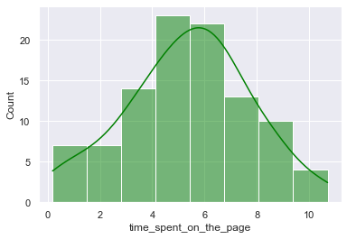

```python
#the time spent bu user is likely a nornal distribution
sns.histplot(df["time_spent_on_the_page"],color="green", kde = True)
plt.show()
```

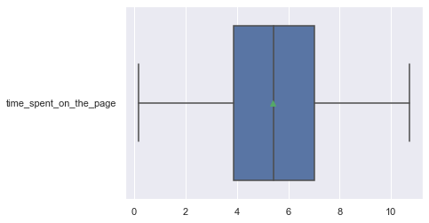

```python
sns.boxplot(data=df[["time_spent_on_the_page","group"]],orient="h",showmeans=True)
```

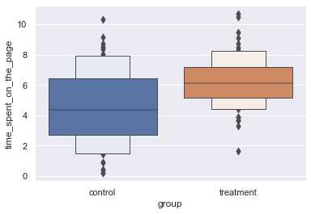

```python
# relationship between time spent on pages  inside the two groups.It seems like the users spent mote time in new landing page
sns.boxenplot(x="group",y="time_spent_on_the_page",data=df)
```

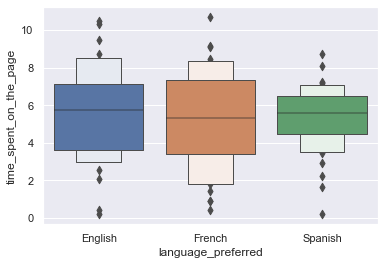

```python
#I am looking to visual of the time time spent according to to language chosen.median is higher for english ans spanish than french users.
sns.boxenplot(x="language_preferred",y="time_spent_on_the_page",data=df)
```

```python
# to continue, I need to convert categorical variables into numerical values. I will first do a copy of df.
df1=df.copy()
```

```python
# translating into numerical  variables with ( code1 = user id, code2=group, code3=landig page, code4=converted, code5=language preferred)
df1['code1']=pd.factorize(df1.user_id)[0]
df1['code2']=pd.factorize(df1.group)[0]
df1['code3']=pd.factorize(df1.landing_page)[0]
df1['code4']=pd.factorize(df1.converted)[0]
df1['code5']=pd.factorize(df1.language_preferred)[0]
```

```python
df1.head()
```

|  | user_id | group | landing_page | time_spent_on_the_page | converted | language_preferred | code1 | code2 | code3 | code4 | code5 |
| --- | --- | --- | --- | --- | --- | --- | --- | --- | --- | --- | --- |
| 0 | 546592 | control | old | 3.48 | no | Spanish | 0 | 0 | 0 | 0 | 0 |
| 1 | 546468 | treatment | new | 7.13 | yes | English | 1 | 1 | 1 | 1 | 1 |
| 2 | 546462 | treatment | new | 4.40 | no | Spanish | 2 | 1 | 1 | 0 | 0 |
| 3 | 546567 | control | old | 3.02 | no | French | 3 | 0 | 0 | 0 | 2 |
| 4 | 546459 | treatment | new | 4.75 | yes | Spanish | 4 | 1 | 1 | 1 | 0 |

```python
df1.describe().T
```

|  | count | mean | std | min | 25% | 50% | 75% | max |
| --- | --- | --- | --- | --- | --- | --- | --- | --- |
| user_id | 100.0 | 546517.0000 | 52.295779 | 546443.00 | 546467.75 | 546492.500 | 546567.2500 | 546592.00 |
| time_spent_on_the_page | 100.0 | 5.3778 | 2.378166 | 0.19 | 3.88 | 5.415 | 7.0225 | 10.71 |
| code1 | 100.0 | 49.5000 | 29.011492 | 0.00 | 24.75 | 49.500 | 74.2500 | 99.00 |
| code2 | 100.0 | 0.5000 | 0.502519 | 0.00 | 0.00 | 0.500 | 1.0000 | 1.00 |
| code3 | 100.0 | 0.5000 | 0.502519 | 0.00 | 0.00 | 0.500 | 1.0000 | 1.00 |
| code4 | 100.0 | 0.5400 | 0.500908 | 0.00 | 0.00 | 1.000 | 1.0000 | 1.00 |
| code5 | 100.0 | 1.0000 | 0.828775 | 0.00 | 0.00 | 1.000 | 2.0000 | 2.00 |

```python
df1.mean()
```

```
user_id                   546517.0000
time_spent_on_the_page         5.3778
code1                         49.5000
code2                          0.5000
code3                          0.5000
code4                          0.5400
code5                          1.0000
dtype: float64
```

```python
print(df.columns)
```

```
Index(['user_id', 'group', 'landing_page', 'time_spent_on_the_page',
       'converted', 'language_preferred'],
      dtype='object')
```

```python
columns_to_show = ["time_spent_on_the_page", "group"]

df.groupby(["landing_page"])[columns_to_show].describe(percentiles=[])
```

| landing_page | time_spent_on_the_page count | time_spent_on_the_page mean | time_spent_on_the_page std | time_spent_on_the_page min | time_spent_on_the_page 50% | time_spent_on_the_page max |
| --- | --- | --- | --- | --- | --- | --- |
| new | 50.0 | 6.2232 | 1.817031 | 1.65 | 6.105 | 10.71 |
| old | 50.0 | 4.5324 | 2.581975 | 0.19 | 4.380 | 10.30 |

A) 2 samples size , N = 50 which are sufficiently large for a z-test which normlay distributed

B) But since the population standard deviation (σ) is unknown, we have to use a t-test.

Degree of Freedom: We have N-1 degrees of freedom : 49 (50-1) for each one

Hypothesis Formulation:

H0:μnew=μold (New landing page mean is equal the mean of old landing page significantly)

Ha:μnew>μold (New landing page mean is greater than the mean of old landing pageraised significantly)

# calculation of the conversion

```python
pd.crosstab(df["converted"], df["language_preferred"], normalize=True)
```

| language_preferred converted | English | French | Spanish |
| --- | --- | --- | --- |
| no | 0.11 | 0.19 | 0.16 |
| yes | 0.21 | 0.15 | 0.18 |

```python
pd.crosstab(df["converted"], df["landing_page"], normalize=True)
```

| landing_page converted | new | old |
| --- | --- | --- |
| no | 0.17 | 0.29 |
| yes | 0.33 | 0.21 |

The conversion rate is greater in the new page than in the old page

```python
pd.crosstab(df["converted"], df["landing_page"], margins=True)
```

| landing_page converted | new | old | All |
| --- | --- | --- | --- |
| no | 17 | 29 | 46 |
| yes | 33 | 21 | 54 |
| All | 50 | 50 | 100 |

• Binomally distributed population - Yes, the visitor is either converted or non-converted. • Random sampling from the population - Yes, we are informed that the collected sample is a simple random sample divided in two. • the binomial distribution can approximated to normal distribution - Yes. The standard thing is to check whether np and n(1-p) are greater than or equal to 10. Here, n and p refer to the sample size and sample proportion respectively. here the sample is n=50 for each for the new page p= 0.66 1-p= 0.34 thus np = 33=> 10 and n(1-p)=0.34*50=17=>10 for the old page p=0.42 and 1-p=0.58 thus np= 0.42*50=21=>10 and n(1-p)=29

Then we choose 2 proportions Z-test here.

hpothesis is :p1, p2 is the conversion rate in the new and old pages H0:p1=p2H0:p1=p2 against the alternate hypothesis Ha:p1≠p2Ha:p1≠p2

the level of significance is at 0.05 for this test.

```python
# import the required fuction
import numpy as np
from statsmodels.stats.proportion import proportions_ztest

# set the counts of defective items
Conversion_count = np.array([21, 33])


# set the sample sizes
nobs = np.array([50, 50])


# find the p-value
test_stat, p_value = proportions_ztest(Conversion_count, nobs)
print('The p-value is ' + str(p_value))
```

```
The p-value is 0.016052616408112556
```

As the p-value is less than the significance level 0.05, we can reject the null hypothesis. Thus,we have enough statistical significance to conclude that the two conversion rates are are different. the conversion rate in new page is greater than the one in old page

```python
pd.crosstab(df["converted"], df["language_preferred"], margins=True)
```

| language_preferred converted | English | French | Spanish | All |
| --- | --- | --- | --- | --- |
| no | 11 | 19 | 16 | 46 |
| yes | 21 | 15 | 18 | 54 |
| All | 32 | 34 | 34 | 100 |

```python
# we want to show the mean time spent by users according to their preferred language
pd.crosstab(df['landing_page'],df['language_preferred'],values=df['time_spent_on_the_page'],aggfunc='mean').fillna('-')
```

| language_preferred landing_page | English | French | Spanish |
| --- | --- | --- | --- |
| new | 6.663750 | 6.196471 | 5.835294 |
| old | 4.454375 | 4.310000 | 4.828235 |

```python
pd.crosstab(df["time_spent_on_the_page"], df["language_preferred"]).mean()
```

```
language_preferred
English    0.340426
French     0.361702
Spanish    0.361702
dtype: float64
```